# Biodiversity Hotspots Exploration ¶

*▓▓▓▓▓▓▓ ▓▓▓▓▓▓▓, ▓▓▓▓▓▓▓, ▓▓▓▓▓▓▓ ▓▓▓▓▓▓▓ ▓▓▓▓▓▓▓; ▓▓▓▓▓▓▓ ▓▓▓▓▓▓▓, ▓▓▓▓▓▓▓ ▓▓▓▓▓▓▓ ▓▓▓▓▓▓▓, ▓▓▓▓▓▓▓*

* Redacted for double blind peer review

[figure not shown]

•••

Last updated: Apr-30-2024, [Carto-Lab Docker](https://gitlab.vgiscience.de/lbsn/tools/jupyterlab) Version 0.14.0

Visualization of temporal patterns for geo-social media posts for [Biodiversity Hotspots](https://www.bfn.de/bpbv-hotspots) in Germany.

# Preparations

```python
import os, sys
from pathlib import Path
import psycopg2
import geopandas as gp
import pandas as pd
import seaborn as sns
import calendar
import textwrap
import matplotlib
import numpy as np
import matplotlib.pyplot as plt
import matplotlib.dates as mdates
import matplotlib.ticker as mticker
import matplotlib.patheffects as pe
from typing import List, Tuple, Dict, Optional, Any
from IPython.display import clear_output, display, HTML
from datetime import datetime
```

```python
module_path = str(Path.cwd().parents[0] / "py")
if module_path not in sys.path:
    sys.path.append(module_path)
from modules.base import tools, hll, preparations
from modules.base.hll import union_hll, cardinality_hll
```

```python
%load_ext autoreload
%autoreload 2
```

```python
OUTPUT = Path.cwd().parents[0] / "out"       # output directory for figures (etc.)
WORK_DIR = Path.cwd().parents[0] / "tmp"     # Working directory
```

```python
(OUTPUT / "figures").mkdir(exist_ok=True)
(OUTPUT / "svg").mkdir(exist_ok=True)
WORK_DIR.mkdir(exist_ok=True)
```

Set global font

```python
plt.rcParams['font.family'] = 'serif'
plt.rcParams['font.serif'] = ['Times New Roman'] + plt.rcParams['font.serif']
```

## Preview Hotspot regions

```python
df_hotspots = gp.read_file(
    Path.cwd().parents[0] / "00_data" / "hotspots" / "hotspots2021.shp")
```

```python
epsg_code = df_hotspots.crs.to_epsg()
print(epsg_code)
```

```
25832
```

Get Shapefile for Germany

```python
source_zip = "https://daten.gdz.bkg.bund.de/produkte/vg/vg2500/aktuell/"
filename = "vg2500_12-31.utm32s.shape.zip"
shapes_name = "vg2500_12-31.utm32s.shape/vg2500/VG2500_LAN.shp"
```

```python
SHAPE_DIR = (OUTPUT / "shapes")
SHAPE_DIR.mkdir(exist_ok=True)

if not (SHAPE_DIR / shapes_name).exists():
    tools.get_zip_extract(uri=source_zip, filename=filename, output_path=SHAPE_DIR)
else:
    print("Already exists")
```

```
Already exists
```

```python
shapes = gp.read_file(SHAPE_DIR / shapes_name)
shapes = shapes.to_crs(f"EPSG:{epsg_code}")
```

Create overlay

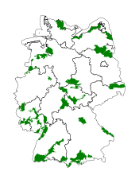

```python
ax = shapes.plot(color='none', edgecolor='black', linewidth=0.2, figsize=(2, 4))
ax = df_hotspots.plot(ax=ax, color='green')
ax.set_axis_off()
```

## Load HLL aggregate data

```python
HOTSPOT_ALL = OUTPUT /  "hotspot_all_months.csv"
METRIC = "postcount"
# METRIC = "usercount"
UPPER_YEAR = 2023
LOWER_YEAR = 2007
```

Preview

```python
data_files = {
    "HOTSPOT_ALL":HOTSPOT_ALL,
    }
tools.display_file_stats(data_files)
```

| name | HOTSPOT_ALL |
| --- | --- |
| size | 8.65 MB |
| records | 12,814 |

```python
df = pd.read_csv(HOTSPOT_ALL)
```

```python
pd.options.display.width = 0
df.head(10)
```

|  | year | month | post_hll | user_hll | hotspot_id | origin_id |
| --- | --- | --- | --- | --- | --- | --- |
| 0 | 2007 | 1 | \x138b405601e3e1 | \x138b4038856e82 | 1 | 2 |
| 1 | 2007 | 1 | \x138b40004600e1046507a1090109210a210a410be110... | \x138b4007a109e1124138853c4440414ae26022616179... | 2 | 2 |
| 2 | 2007 | 1 | \x138b404d218365 | \x138b40ebc1 | 3 | 2 |
| 3 | 2007 | 1 | \x138b40000301410241032404c105c3068306e109c20a... | \x138b4009e11ee3218421a6228122e128412ea135e13a... | 4 | 2 |
| 4 | 2007 | 1 | \x138b4001c21162470156226e2178a18e41a6e1b661eee3 | \x138b40e682 | 5 | 2 |
| 5 | 2007 | 1 | \x138b4004630783148314e11ec226a329a32bc12da237... | \x138b402fc136233da165a46d228b61b8c2c402df66ec82 | 6 | 2 |
| 6 | 2007 | 1 | \x138b40012303a207a3090109610b030be30c8111011d... | \x138b4003410781110115e11f022ea837a543a39883b9... | 7 | 2 |
| 7 | 2007 | 1 | \x138b40016303e105440c240e630f8111a113e2142215... | \x138b407421c181efe1f1c1 | 8 | 2 |
| 8 | 2007 | 1 | \x138b403ec63f6357c17f8281218c23a163a4a1cc01ee... | \x138b4002611fa18ba39702d724 | 9 | 2 |
| 9 | 2007 | 1 | \x138b4000610142018102c20901098210621181122216... | \x138b4001a605821d011d83216222622fc23101388241... | 10 | 2 |

Get distinct hotspot_ids, to check completeness:

```python
print(sorted(df['hotspot_id'].unique()))
```

```
[1, 2, 3, 4, 5, 6, 7, 8, 9, 10, 11, 12, 13, 14, 15, 16, 17, 18, 19, 20, 21, 22, 23, 24, 25, 26, 27, 28, 29, 30]
```

## Connect hll worker db

```python
DB_USER = "hlluser"
DB_PASS = os.getenv('READONLY_USER_PASSWORD')
# set connection variables
DB_HOST = "127.0.0.1"
DB_PORT = "5452"
DB_NAME = "hllworkerdb"
```

Connect to empty Postgres database running HLL Extension:

```python
DB_CONN = psycopg2.connect(
        host=DB_HOST,
        port=DB_PORT ,
        dbname=DB_NAME,
        user=DB_USER,
        password=DB_PASS
)
DB_CONN.set_session(
    readonly=True)
DB_CALC = tools.DbConn(
    DB_CONN)
CUR_HLL = DB_CONN.cursor()
```

```python
db_conn = tools.DbConn(DB_CONN)
```

## Calculate HLL Cardinality per month

Define additional functions for reading and formatting CSV as `pd.DataFrame`

```python
TIMESTAMP_FORMAT = '%Y %m'

def read_csv_datetime(csv: Path, timestamp_format: str = TIMESTAMP_FORMAT) -> pd.DataFrame:
    """Read CSV with parsing datetime index (months)

        First CSV column: Year
        Second CSV column: Month
    """
    date_cols = ["year", "month"]
    df = pd.read_csv(
        csv, index_col='datetime',
        parse_dates={'datetime':date_cols},
        date_format=timestamp_format,
        keep_date_col='False')
    df.drop(columns=date_cols, inplace=True)
    return df

def append_cardinality_df(df: pd.DataFrame, hll_col: str = "post_hll", cardinality_col: str = 'postcount_est'):
    """Calculate cardinality from HLL and append to extra column in df"""
    df[cardinality_col] = df.apply(
        lambda x: cardinality_hll(
           x[hll_col], CUR_HLL),
        axis=1)
    df.drop(columns=[hll_col], inplace=True)
    return df

def filter_fill_time(
        df: pd.DataFrame, min_year: int,
        max_year: int, val_col: str = "postcount_est",
        min_month: int = 1, max_month: int = 1):
    """Filter time values between min - max year and fill missing values"""
    min_date = pd.Timestamp(f'{min_year}-{min_month}-01')
    max_date = pd.Timestamp(f'{max_year}-{max_month}-01')
    # clip by start and end date
    if not min_date in df.index:
        df.loc[min_date, val_col] = 0
    if not max_date in df.index:
        df.loc[max_date, val_col] = 0
    df.sort_index(inplace=True)
    # mask min and max time
    time_mask = ((df.index >= min_date) & (df.index <= max_date))
    # fill missing months with 0
    # this will also set the day to max of month
    series = df.loc[time_mask][val_col].resample('M').sum().fillna(0)
    return series.to_frame()
```

Apply functions to all data sets.

```python
df_post = read_csv_datetime(HOTSPOT_ALL)
```

```python
source_names = {
    1: "Instagram", 2: "Flickr", 3: "Twitter", 23: "iNaturalist"}
```

Split by data source, create copies of original dataframe., and process.

```python
def process_df(
        df: pd.DataFrame, metric: str = METRIC, upper_year: int = UPPER_YEAR, lower_year: int = LOWER_YEAR):
    """Process df: append_cardinality() and filter_fill_time()"""
    if metric == "postcount":
        hll_col= "post_hll"
        cardinality_col = 'postcount_est'
    else:
        hll_col= "user_hll"
        cardinality_col = 'usercount_est'
    df = append_cardinality_df(df, hll_col, cardinality_col)
    df = filter_fill_time(df, lower_year, upper_year, cardinality_col)
    # fill where no data avilable
    df.fillna(0, inplace=True)
    return df
```

```python
vis_df = []
for idx, name in source_names.items():
    sel_df = df_post[df_post["origin_id"]==idx].copy()
    vis_df.append(process_df(sel_df))
```

```python
vis_df[0].head(5)
```

| datetime | postcount_est |
| --- | --- |
| 2007-01-31 | 0.0 |
| 2007-02-28 | 0.0 |
| 2007-03-31 | 0.0 |
| 2007-04-30 | 0.0 |
| 2007-05-31 | 0.0 |

```python
def plot_lines(
        df_list: List[pd.DataFrame],
        xlegend: str = "Year", title: Optional[str] = None, metric: str = METRIC):
    """Plot lines from a list of DataFrames"""
    if metric == "postcount":
        hll_col: str = "post_hll"
        cardinality_col: str = 'postcount_est'
        ylegend: str = "Post count"
    else:
        hll_col: str = "user_hll"
        cardinality_col: str = 'usercount_est'
        ylegend: str = "User count"
    fig, ax = plt.subplots()
    fig.set_size_inches(15.7, 4.27)
    ylabel = f'{ylegend} (estimate)'
    for ix, df in enumerate(df_list):
        source_name = source_names.get(list(source_names)[ix])
        ax = df[cardinality_col].plot(ax=ax, kind='line', label=source_name)
    tick_loc = mticker.MultipleLocator(12)
    # x axis ticker formatting
    ax.xaxis.set_major_locator(tick_loc)
    ax.yaxis.set_major_formatter(mticker.StrMethodFormatter('{x:,.0f}'))
    ax.tick_params(axis='x', rotation=45, color='grey')
    ax.set(xlabel=xlegend, ylabel=ylegend)
    ax.spines["left"].set_linewidth(0.25)
    ax.spines["bottom"].set_linewidth(0.25)
    ax.spines["top"].set_linewidth(0)
    ax.spines["right"].set_linewidth(0)
    ax.yaxis.set_tick_params(width=0.5)
    # add legend
    h, l = ax.get_legend_handles_labels()
    ax.legend(h, l, frameon=False, loc='best')
    if title:
        ax.set_title(title)
```

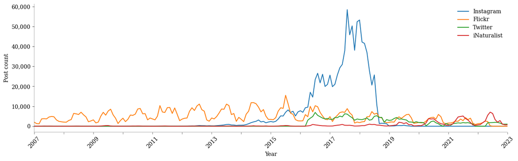

```python
plot_lines(vis_df)
```

## Group temporal patterns by month

First, merge into single dataframe

```python
stacked_df = pd.DataFrame()
for ix, df in enumerate(vis_df):
    source_name = source_names.get(list(source_names)[ix])
    stacked_df[source_name] = df
    stacked_df.index = df.index
```

```python
stacked_df.head()
```

| datetime | Instagram | Flickr | Twitter | iNaturalist |
| --- | --- | --- | --- | --- |
| 2007-01-31 | 0.0 | 2007.0 | 0.0 | 0.0 |
| 2007-02-28 | 0.0 | 1303.0 | 0.0 | 0.0 |
| 2007-03-31 | 0.0 | 1231.0 | 0.0 | 7.0 |
| 2007-04-30 | 0.0 | 3692.0 | 0.0 | 10.0 |
| 2007-05-31 | 0.0 | 3787.0 | 0.0 | 73.0 |

Total sums:

```python
stacked_df.sum()
```

```
Instagram      997221.0
Flickr         915781.0
Twitter        221104.0
iNaturalist    117023.0
dtype: float64
```

```python
BAR_PARAM = {
    "width":1.0,
    "label":f"Total {METRIC} aggregated for months",
    "edgecolor":"white",
    "linewidth":0.5,
    "alpha":0.7,
}

def plot_bars(
        df: pd.DataFrame, ax: matplotlib.axes = None, title: str = None,
        ytitle: float = None, padtitle: float = None, legend: bool = None,
        bar_param: Dict[str, Any] = BAR_PARAM, title_legend: str = None,
        xlegend: float = None, ylegend: float = None, lang: str = None):
    """Plot stacked bars from a DataFrame with multiple columns"""
    colors = sns.color_palette("vlag", as_cmap=True, n_colors=2)
    if lang is None:
        lang = "en"
    # create figure
    if not ax:
        fig, ax = plt.subplots(1, 1, figsize=(3, 1.5))
    colors = sns.color_palette("bright", as_cmap=True, n_colors=4)
    # plot
    # calculate mean:
    # exclude months with no data in mean calculation:
    df.replace(0, np.NaN) \
        .groupby(df.index.month, dropna=True) \
        .mean() \
        .plot.bar(ax=ax, stacked=True, color = colors, **bar_param)
    # format
    ax.set_xlim(-0.5,11.5)
    if lang == "en":
        month_names = ['Jan','Feb','Mar','Apr','May','Jun',
                   'Jul','Aug','Sep','Oct','Nov','Dec']
    elif lang == "de":
        month_names = ['Jan','Feb','Mär','Apr','Mai','Jun',
                       'Jul','Aug','Sep','Okt','Nov','Dez']
    ax.set_xticklabels(month_names)
    ax.tick_params(axis='x', rotation=45, length=0) # length: of ticks
    ax.spines["left"].set_linewidth(0.25)
    ax.spines["bottom"].set_linewidth(0.25)
    ax.spines["top"].set_linewidth(0)
    ax.spines["right"].set_linewidth(0)
    ax.yaxis.set_tick_params(width=0.5)
    ax.set(xlabel="", ylabel="")
    if legend:
        if xlegend is None:
            xlegend = 1.0
        if ylegend is None:
            ylegend = 1
        ax.legend(
            bbox_to_anchor=(xlegend, ylegend), loc='upper left',
            fontsize=8, frameon=False, title=title_legend, title_fontsize=8)
    else:
        ax.legend().set_visible(False)
    if not title:
        title = f"{METRIC.capitalize()} per month (mean)"
    if ytitle is None:
        ytitle =-0.2
    if padtitle is None:
        padtitle=-14
    ax.set_title(title, y=ytitle, pad=padtitle)
    for item in (
        [ax.xaxis.label, ax.title, ax.yaxis.label] +
         ax.get_xticklabels() + ax.get_yticklabels()):
            item.set_fontsize(8)
```

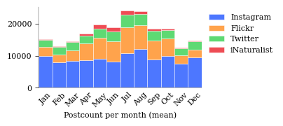

```python
plot_bars(df=stacked_df, legend=True)
```

Visualize for all Hotspots separately.

```python
hotspots = df_post['hotspot_id'].unique()
print(len(hotspots))
```

```
30
```

Get summary of total posts per Hotspots, for sorting:

```python
def replace_datetime_with_month(df: pd.DataFrame, group_by: str = "hotspot_id"):
    """Extract month from datetime index, set as new composite index
    together with topic_group"""
    df.set_index([df.index.month, group_by], inplace=True)
    df.index.rename(("month", group_by), inplace=True)
```

Union user count column, to get total user aggregate data

```python
df_post = read_csv_datetime(HOTSPOT_ALL)
replace_datetime_with_month(df_post)
cardinality_series = tools.union_hll_series(
    hll_series=df_post["user_hll"],
    db_conn=db_conn, multiindex=True)
df = cardinality_series.to_frame()
df.rename(columns={"hll_cardinality":"user_count"}, inplace=True)
hotspots_sorted = df.unstack(level=1).fillna(0).droplevel(0, axis=1).sum().sort_values(ascending=False)
```

Get hotspot labels

Preview ranking order

First: Get Hotspot names for x-labels

- we also shorten a number of very long names

```python
hotspot_names = {}
for idx in hotspots_sorted.index:
    hotspot_name = df_hotspots[df_hotspots["NUMMER"]==idx].NAME.iloc[0]
    hotspot_names[idx] = hotspot_name
    print(f'{idx} - {hotspot_name} - Postcount: {hotspots_sorted[idx]}')
hotspot_names[27] = "Schleswig-Holsteinische Ostseeküste"
hotspot_names[24] = "Untere Wümmeniederung mit Teufelsmoor"
hotspot_names[13] = "Saar-Ruwer-Hunsrück, Hoch- und Idarwald"
hotspot_names[23] = "Hunte-Leda-Moorniederung, Delmenhorster G."
hotspot_names[18] = "Südharzer Zechsteingürtel, Kyffhäuser und H."
```

```
2 - Ammergebirge, Niederwerdenfelser Land und Obere Isar - Postcount: 159119
4 - Ammer-Loisach-Hügelland und Lech-Vorberge - Postcount: 101458
10 - Nördliche Oberrheinebene mit Hardtplatten - Postcount: 80058
12 - Mittelrheintal mit den Seitentälern Nahe und Mosel - Postcount: 51771
19 - Harz - Postcount: 43781
6 - Schwarzwald mit Alb-Wutach-Gebiet - Postcount: 38691
7 - Schwäbische Alb - Postcount: 35382
27 - Schleswig-Holsteinische Ostseeküste mit Angeln, Schwansen und Dänischer Wohld - Postcount: 33830
16 - Thüringer Wald und nördliche Vorländer - Postcount: 27456
30 - Usedom und Ostvorpommersche Küste - Postcount: 26928
29 - Vorpommersche Boddenlandschaft und Rostocker Heide - Postcount: 25428
25 - Mecklenburgisch-Brandenburgisches Kleinseenland - Postcount: 24717
11 - Donnersberg, Pfälzerwald und Haardtrand - Postcount: 20936
8 - Hinterer Bayerischer Wald - Postcount: 16984
28 - Westmecklenburgische Ostseeküste und Lübecker Becken - Postcount: 16413
13 - Saar-Ruwer-Hunsrück, Hoch- und Idarwald und Oberes Nahebergland - Postcount: 15263
1 - Allgäuer Alpen - Postcount: 14186
20 - Oberlausitzer Heide- und Teichlandschaften - Postcount: 14052
22 - Südliches Emsland und nördliche westfälische Bucht - Postcount: 12809
5 - Oberschwäbisches Hügelland und Adelegg - Postcount: 10490
9 - Nördliche Frankenalb - Postcount: 10233
15 - Rhön - Postcount: 9083
18 - Südharzer Zechsteingürtel, Kyffhäuser und Hainleite - Postcount: 8969
26 - Schorfheide mit Neuenhagener Oderinsel - Postcount: 8656
24 - Untere Wümmeniederung mit Teufelsmoor und Wesermünder Geest - Postcount: 8043
3 - Alpenvorland zwischen Mangfall und Inn - Postcount: 7676
14 - Kalk- und Vulkaneifel - Postcount: 6918
17 - Werratal mit Hohem Meißner und Kaufunger Wald - Postcount: 6466
23 - Hunte-Leda-Moorniederung, Delmenhorster Geest und Hümmling - Postcount: 5513
21 - Senne mit angrenzendem Teutoburger Wald - Postcount: 3579
```

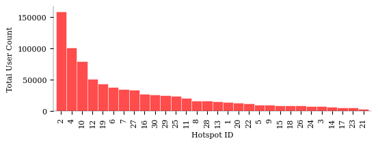

```python
ax = hotspots_sorted.plot.bar(figsize=(6, 2), fontsize=8, color="r", **BAR_PARAM)
ax.spines["left"].set_linewidth(0.25)
ax.spines["bottom"].set_linewidth(0.25)
ax.spines["top"].set_linewidth(0)
ax.spines["right"].set_linewidth(0)
ax.set(xlabel="Hotspot ID", ylabel="Total User Count")
ax.xaxis.label.set_fontsize(8)
ax.yaxis.label.set_fontsize(8)
```

```python
df_post = read_csv_datetime(HOTSPOT_ALL)
```

```python
SUBPLOTS = len(hotspots_sorted) # 30 Subplots
```

```python
hotspots_sorted
```

```
hotspot_id
2     159119
4     101458
10     80058
12     51771
19     43781
6      38691
7      35382
27     33830
16     27456
30     26928
29     25428
25     24717
11     20936
8      16984
```

[output cut: 17 more lines]

```python
hotspot_names
```

```
{2: 'Ammergebirge, Niederwerdenfelser Land und Obere Isar',
 4: 'Ammer-Loisach-Hügelland und Lech-Vorberge',
 10: 'Nördliche Oberrheinebene mit Hardtplatten',
 12: 'Mittelrheintal mit den Seitentälern Nahe und Mosel',
 19: 'Harz',
 6: 'Schwarzwald mit Alb-Wutach-Gebiet',
 7: 'Schwäbische Alb',
 27: 'Schleswig-Holsteinische Ostseeküste',
 16: 'Thüringer Wald und nördliche Vorländer',
 30: 'Usedom und Ostvorpommersche Küste',
 29: 'Vorpommersche Boddenlandschaft und Rostocker Heide',
 25: 'Mecklenburgisch-Brandenburgisches Kleinseenland',
 11: 'Donnersberg, Pfälzerwald und Haardtrand',
 8: 'Hinterer Bayerischer Wald',
 28: 'Westmecklenburgische Ostseeküste und Lübecker Becken',
 13: 'Saar-Ruwer-Hunsrück, Hoch- und Idarwald',
 1: 'Allgäuer Alpen',
 20: 'Oberlausitzer Heide- und Teichlandschaften',
 22: 'Südliches Emsland und nördliche westfälische Bucht',
 5: 'Oberschwäbisches Hügelland und Adelegg',
 9: 'Nördliche Frankenalb',
 15: 'Rhön',
 18: 'Südharzer Zechsteingürtel, Kyffhäuser und H.',
 26: 'Schorfheide mit Neuenhagener Oderinsel',
 24: 'Untere Wümmeniederung mit Teufelsmoor',
 3: 'Alpenvorland zwischen Mangfall und Inn',
 14: 'Kalk- und Vulkaneifel',
 17: 'Werratal mit Hohem Meißner und Kaufunger Wald',
 23: 'Hunte-Leda-Moorniederung, Delmenhorster G.',
 21: 'Senne mit angrenzendem Teutoburger Wald'}
```

```python
lang = "en"
```

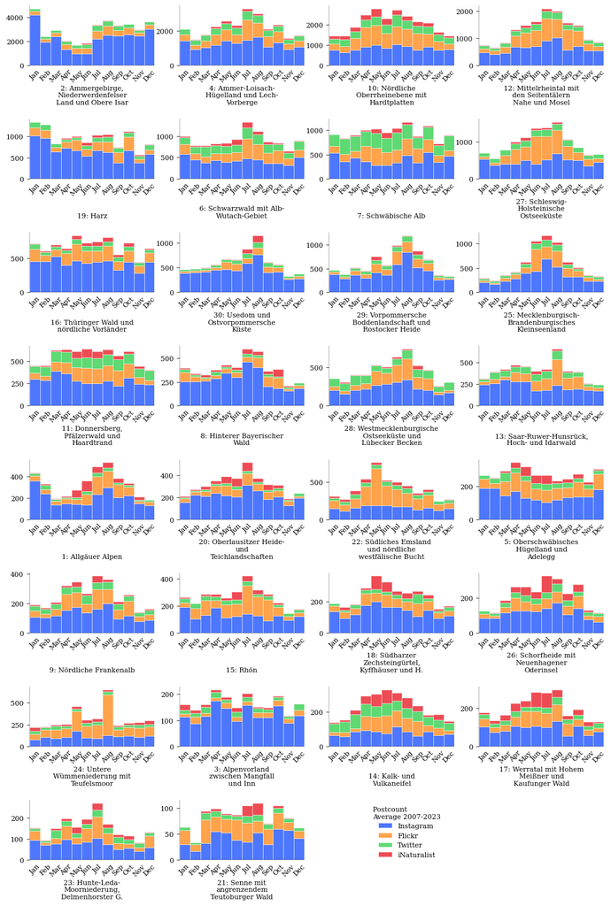

```python
# create figure object with multiple subplots
fig, axes = plt.subplots(nrows=int(round(SUBPLOTS/4)), ncols=4, figsize=(12, 18))
fig.subplots_adjust(hspace=.9) # adjust vertical space, to allow title below plot
# remove subplots beyond 30
fig.delaxes(axes[7][2])
fig.delaxes(axes[7][3])
# iterate hotspots
for ix, ax in enumerate(axes.reshape(-1)):
    if ix >= SUBPLOTS:
        break
    hotspot_id = list(hotspot_names.keys())[ix]
    hotspot_name = textwrap.fill(hotspot_names.get(hotspot_id), 20)
    # filter np_str and calculate cardinality
    df_post_filter = df_post[df_post["hotspot_id"]==hotspot_id].copy()
    stacked_df = pd.DataFrame()
    # process and stack into single df
    for idx, name in source_names.items():
        sel_df = df_post_filter[df_post_filter["origin_id"]==idx].copy()
        processed_df = process_df(sel_df)
        stacked_df[name] = processed_df
        stacked_df.index = processed_df.index
    # plot bars individually
    plot_kwargs = {
        "ytitle":-0.65,
        "padtitle":0,
        "legend":False,
        "lang":lang
    }
    avrg_txt = "Average"
    if lang == "de":
        avrg_txt = "Durchschnitt"
    if ix == SUBPLOTS-1:
        # add legend on last subplot
        plot_kwargs["legend"] = True
        plot_kwargs["xlegend"] = 1.5
        plot_kwargs["title_legend"] = f'{METRIC.capitalize()} \n{avrg_txt} {LOWER_YEAR}-{UPPER_YEAR}'
    plot_bars(
        df=stacked_df, title=f'{hotspot_id}: {hotspot_name}', ax=ax, **plot_kwargs)
```

save as svg and png

```python
tools.save_fig(fig, output=OUTPUT, name=f"hotspots_months_{METRIC}")
```

Create map with labels for paper Figure. Select Hotspots `2`, `14`, and `25`.

```python
df_sel = df_hotspots[df_hotspots["NUMMER"].isin([2, 14, 25])]
```

```python
df_sel
```

|  | NAME | FLAECHE | GLS | NUMMER | FLAECHEQKM | area_ha | STATUS | geometry |
| --- | --- | --- | --- | --- | --- | --- | --- | --- |
| 3 | Ammergebirge, Niederwerdenfelser Land und Ober... | 48785.121903 | Alpen | 2 | 487.851219 | 48785.12190 | 1 | POLYGON ((661082.685 5274264.900, 661102.380 5... |
| 8 | Kalk- und Vulkaneifel | 95624.595511 | Westliches Mittelgebirge | 14 | 956.245955 | 95624.59551 | 0 | POLYGON ((343378.545 5608504.928, 343387.481 5... |
| 9 | Mecklenburgisch-Brandenburgisches Kleinseenland | 230640.189646 | Nordostdeutsches Tiefland | 25 | 2516.392460 | 251638.81344 | 0 | POLYGON ((746802.676 5937303.491, 747012.020 5... |

manually create label offset

```python
label_off = {
    2:(0, 200000),
    14:(200000, 0),
    25:(-200000, 0)}
label_rad = {
    2:0.1,
    14:0.5,
    25:-0.3}
```

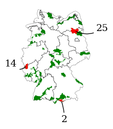

```python
fig, ax = plt.subplots(1, 1, figsize=(2, 4))
ax = shapes.plot(ax=ax, color='none', edgecolor='black', linewidth=0.2, figsize=(2, 4))
ax = df_hotspots.plot(ax=ax, color='green')
ax = df_sel.plot(ax=ax, color='red')
tools.annotate_locations(
    gdf=df_sel, ax=ax, label_off=label_off, label_rad=label_rad,
    text_col="NUMMER", arrowstyle='-', arrow_col='black', fontsize=14)
ax.set_axis_off()
```

```python
tools.save_fig(fig, output=OUTPUT, name=f"overview_hotspots")
```

# Create Release File

First convert all svg to pdf, for archive purposes and paper submission.

```python
WEB_DRIVER = preparations.load_chromedriver()
```

```
Chromedriver loaded. Svg output enabled.
```

```python
%%time
tools.convert_svg_pdf(in_dir=OUTPUT / "svg", out_dir=OUTPUT / "pdf")
```

```
Processed 21 of 21 files..
CPU times: user 3.05 s, sys: 3.08 s, total: 6.14 s
Wall time: 35.7 s
```

**Create release file with all results**

Create a release file that contains ipynb notebooks, HTML, figures, svg and python converted files.

Make sure that 7z is available (`apt-get install p7zip-full`)

```python
!cd .. && git config --system --add safe.directory '*' \
    && RELEASE_VERSION=$(git describe --tags --abbrev=0) \
    && 7z a -tzip -mx=9 out/release_$RELEASE_VERSION.zip \
    md/* py/* out/*.csv resources/* out/pdf/* out/svg/* \
    out/figures/* notebooks/*.ipynb \
    README.md jupytext.toml nbconvert.tpl \
    -x!py/__pycache__ -x!py/modules/__pycache__ -x!py/modules/.ipynb_checkpoints \
    -y > /dev/null
```

# Create notebook HTML

```python
!jupyter nbconvert --to html_toc \
    --output-dir=../resources/html/ ./05_hotspots.ipynb \
    --template=../nbconvert.tpl \
    --ExtractOutputPreprocessor.enabled=False >&- 2>&-
```